# Project1 - PSL 598, Fall 2022

Alejandro Pimentel (netID ap41,UIN 659282110)

## Predict the Housing Prices in Ames

### Data set

- TITLE: Ames Iowa: Alternative to the Boston Housing Data Set.
- SIZE: 2930 observations, 82 variables

Ames_data.csv contains information from the Ames Assessor’s Office used in computing assessed values for individual residential properties sold in Ames, IA from 2006 to 2010.

The first column is `PID`, the Parcel identification number; The last column is the response variable, `Sale_Price`; The remaining 81 columns are explanatory variables describing various aspects of residential homes.

### Goal

The goal is to predict the price of a home (in log scale) with those explanatory variables. We built TWO prediction models:

- Variable selection with Lasso followed by Ridge Regression using those variables.
- Boosting tree.

Both models are tested on 10 predefined splits. For the first 5 splits the benchmark to beat is `0.125` and for the remaining 5 is `0.135`.

### Pre-Procesing

For both types of models the data was processed as follows:

1. Removed predictors which 96% or more of its values are the same. Example:

```
## [1] "### Heating ###"
```

```
##    Var1 Freq  percentage
## 1 Floor    1  0.03412969
## 2  GasA 2885 98.46416382
## 3  GasW   27  0.92150171
## 4  Grav    9  0.30716724
## 5  OthW    2  0.06825939
## 6  Wall    6  0.20477816
```

In the code the function `drop_irrelevant` is used for this step.

2. For continuous predictors we applied a `winsorization` function at quantile cut of 95%.

For example, the distribution for `Lot_Area` shows most values being under ~15000 sq. ft.

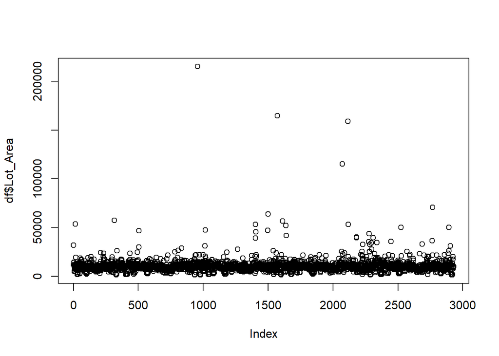

After applying winsorization we bring potential outliers closer to the rest of the data points.

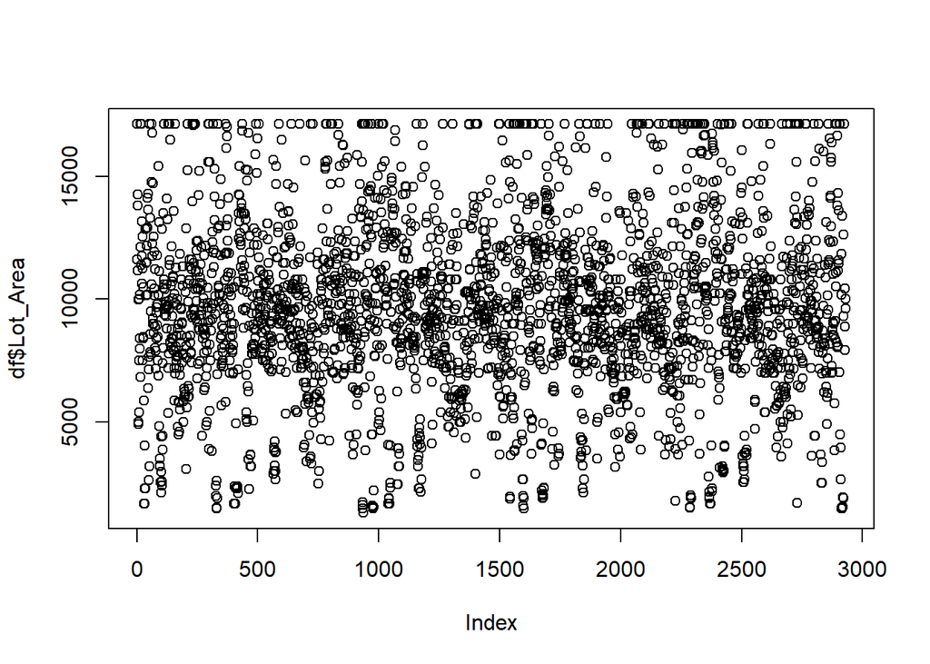

3. The categorical variables were encoded as `K dummy variables` where `K` is the number of levels. Example:

```
## [1] "Foundation"
```

```
## [1] "BrkTil" "CBlock" "PConc"  "Slab"   "Stone"  "Wood"
```

```
## [1] "Foundation_BrkTil" "Foundation_CBlock" "Foundation_PConc"
## [4] "Foundation_Slab"   "Foundation_Stone"  "Foundation_Wood"
```

`expand_factors` function is used for this step.

4. For missing values, only `Garage_Yr_Blt` had `NA` values which we set to `0`.
5. Based on the correlation of some continuous predictors with `Sale_Price` we tried non-linear transformations without almost any performance improvement. So those were removed from the final version.
6. Although originally the pre-processing diverged for the 2 models, as testing progressed, both ended up using the same pre-processed data.

## Implementation

### Models

For the first model we used `gmlet` with $alpha=1$ (Lasso), to perform variable selection. Then we used `ridge` regression using those variables.

In the second model we got the best results with `boosting`, specifically used `R` implementation `xgboost`.

### Transformation of the test data.

Since the test data might have categorical values not present during the training phase, we remove them before predicting. In other words, we conciliate the predictors in the test data with those observed in the training set.

The functions used for this are:

- `order_predictors`
- `conciliate_predictors`

## Results

*Computer System used: Intel i7-8850H CPU @ 2.6GHz, RAM 48.0 GB*

Although both models have very similar results, we can notice a few points:

- For the first 5 splits, boosting performs slightly better.
- Boosting takes longer to train.

RMSE and training times per data split

| Split # | RMSE Lasso | RMSE Boosting | Benchmark | Lasso training time (s) | Boosting training time (s) |
| --- | --- | --- | --- | --- | --- |
| 1 | 0.12471 | 0.11686 | 0.125 | 3.11 | 44.31 |
| 2 | 0.12087 | 0.11902 | 0.125 | 2.53 | 46.71 |
| 3 | 0.11977 | 0.11608 | 0.125 | 2.66 | 43.69 |
| 4 | 0.12143 | 0.11377 | 0.125 | 2.71 | 40.88 |
| 5 | 0.11406 | 0.10727 | 0.125 | 2.53 | 37.86 |
| 6 | 0.13228 | 0.12868 | 0.135 | 2.87 | 46.29 |
| 7 | 0.12546 | 0.13330 | 0.135 | 2.27 | 45.39 |
| 8 | 0.11845 | 0.12417 | 0.135 | 2.43 | 44.45 |
| 9 | 0.13029 | 0.13226 | 0.135 | 3.41 | 43.33 |
| 10 | 0.12471 | 0.12683 | 0.135 | 2.60 | 37.64 |

### Comparing both RMSE results for each type of model.

Both models performance is very similar. One could argue `variance` for `Boosting` is a bit higher but the difference is very small when looking at the numbers.

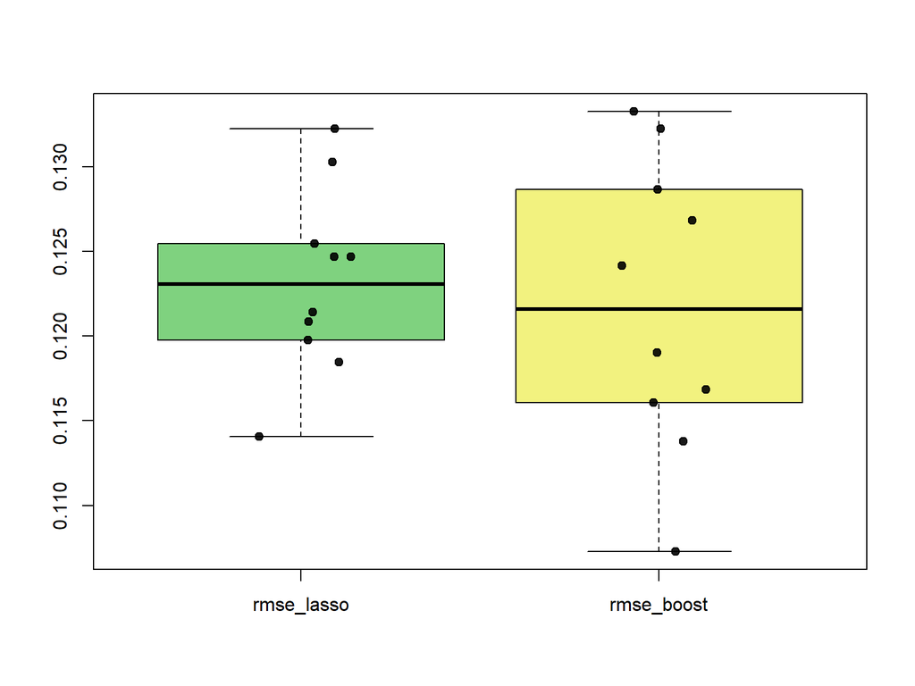